## IA & Data science (3i026) -- 2018-2019

*© Equipe pédagogique: Manon Ansart, Vincent Guigue, Marie-Jeanne Lesot, Christophe Marsala, Olivier Schwander.*

# TD-TME06: méthodes d'ensembles

L'objectif de ce TP est d'implémenter des méthodes d'ensembles et de les évaluer. Dans un premier temps, on se focalisera sur l'algorithme de bagging appliqué aux arbres de décision, puis on passera au random forests.

Comme précédemment, on ne considére que le cas où les attributs sont tous numériques.

**[Q]** **Indiquer dans la boîte ci-dessous vos noms et prénoms :**

*Double-cliquer ici et insérer les noms et prénoms de votre binôme*

**[Q]** **Renommer ce fichier ipython**

Tout en haut de cette page, cliquer sur `tme-06` et rajouter à la suite de `tme-06` les noms des membres du binômes séparés par un tiret.

Charger la librairie `iads` pour avoir accès aux fonctions déjà écrites.

```python
import numpy as np
import pandas as pd
import matplotlib.pyplot as plt
%matplotlib inline

# La ligne suivante permet de préciser le chemin d'accès à la librairie iads
import sys
sys.path.append('../')

# Importation de la librairie iads
import iads as iads

# importation de LabeledSet
from iads import LabeledSet as ls

# importation de Classifiers
from iads import Classifiers as cl

# importation de utils
from iads import utils as ut
```

Pour tester les fonctions à implémenter dans cette séance, on utilise la base d'exemples suivante :

```python
# Base d'exemples pour tester les fonctions:
set_exemples = ls.LabeledSet(2)
set_exemples.addExample([2.10492662303,1.10648470933],1)
set_exemples.addExample([0.297525816499,-0.662504551625],1)
set_exemples.addExample([1.6694258992,0.313687975072],1)
set_exemples.addExample([1.20583098523,3.50817309097],1)
set_exemples.addExample([1.13739407316,1.96688273992],1)
set_exemples.addExample([2.32319808376,0.536577798714],1)
set_exemples.addExample([-0.953004346997,0.596926923927],1)
set_exemples.addExample([1.00574784804,-0.0959606771199],1)
set_exemples.addExample([0.747509778063,0.429544908608],1)
set_exemples.addExample([1.39048336283,0.442578873406],1)
set_exemples.addExample([0.0470799329584,-1.97596265858],-1)
set_exemples.addExample([-0.673998013071,0.0693931940855],-1)
set_exemples.addExample([-0.84587451642,0.761766191612],-1)
set_exemples.addExample([-1.39596839858,-0.943807082082],-1)
set_exemples.addExample([0.319301767707,0.566169775123],-1)
set_exemples.addExample([1.43459714786,0.935712030926],-1)
set_exemples.addExample([-1.69323475458,-1.89563184035],-1)
set_exemples.addExample([0.81167008598,-1.17927660655],-1)
set_exemples.addExample([-1.03264043689,-1.08118488864],-1)
set_exemples.addExample([0.609517439986,-2.88593327349],-1)
```

## Etape 1: retours sur la séance 5

**[Q]** Modifier la fonction `shannon()` afin qu'elle puisse s'appliquer sur une liste vide ou sur une liste à un seul élément: dans ce cas-là, la fonction rend $0.0$.

```python
# Exemples d'utilisation:
print("P=[]  : ", shannon([]))
print("P=[1] : ", shannon([1]))
```

```
P=[]  :  0.0
P=[1] :  0.0
```

Recopier les fonctions suivantes à partir de votre notebook du TD-TME05.

- classe_majoritaire(LSet)
- entropie(LSet)
- discretise(LSet, col)
- divise(LSet,att,seuil)
- construit_AD(LSet,epsilon)

ainsi que les classes:

- class ArbreBinaire
- class ArbreDecision

Remplissez la boite suivante en recopiant toutes ces fonctions et classes du TD_TME05.

**[Q]** Modifier la fonction `construit_ad` afin d'utiliser le gain d'information comme critère d'arrêt.

L'algorithme est modifié ainsi:

Pour construire un arbre de décision, il faut réaliser les étapes suivantes:

- si l'entropie de Shannon de l'ensemble courant est inférieure à epsilon (réel positif fixé et qui est un paramètre de l'algorithme), alors construire une feuille avec cet ensemble, la classe associée à cette feuille est la classe majoritaire;
- sinon, pour chaque attribut, calculer le seuil de discrétisation et l'entropie de Shannon correspondante
  - choisir l'attribut qui donne une valeur d'entropie minimale
  - regarder le gain d'information apporté par le test sur les valeurs de cet attribut
    - si ce gain est inférieur à epsilon alors construire une feuille avec l'ensemble
    - sinon l'attribut choisi sert à constituer un noeud de l'arbre de décision, les arcs issus de ce noeud sont labeller par un test (inférieur ou égal ou supérieur) par rapport au seuil trouvé

On rappelle (cf. cours) que le gain d'information vaut:

$$I-s(A_j,Y) = D(Y) - Q_Y(A_j)$$

avec $D(Y)$, l'entropie de Shannon de l'ensemble courant, et $Q_Y(A_j)$ l'entropie de de la classe pour la coupure par le seuil trouvé sur l'attribut $A_j$).

## Etape 2: Bagging d'arbres de décision

### Tirage aléatoire d'exemples

Le bootstrap s'effectue en tirant aléatoirement un échantillon de $m$ exemples à partir de la base d'apprentissage $X$. Cet échantillon sert ensuite à construire un classifieur.

Dans l'algorithme du bagging, ce processus est répété $B$ fois.

Afin de ne pas alourdir la place mémoire nécessaire pour réaliser un tel tirage, on ne travaille que sur les indices des exemples dans la base. Un **échantillon de $X$ est donc un vecteur d'entiers** qui représentent les indices des exemples choisis.

#### Tirages aléatoires en Python

Consulter la librairie Python random qui propose différentes fonctions utiles pour implémenter le tirage aléatoire du bootstrap.

Par exemple, la fonction `sample()` de la librairie `random` rend une sélection aléatoire dans une population donnée en réalisant un tirage sans remise.

Pour tester, exécuter plusieurs fois les instructions de la boîte suivante :

```python
import random
L= [i for i in range(0,11)]             # construction de la liste des entiers de 0 à 10
print("La liste L de départ: ",L)
EchL = random.sample(L,6)               # tirage de 6 éléments de L
print("Echantillon: ",EchL)
```

```
La liste L de départ:  [0, 1, 2, 3, 4, 5, 6, 7, 8, 9, 10]
Echantillon:  [5, 4, 9, 0, 2, 6]
```

La fonction `choice()` permet de choisir aléatoirement un élément:

```python
L= [i for i in range(0,11)]             # construction de la liste des entiers de 0 à 10
print("La liste L de départ: ",L)
elt = random.choice(L)                  # choix d'un élémént
print("Element choisi: ",elt)
```

```
La liste L de départ:  [0, 1, 2, 3, 4, 5, 6, 7, 8, 9, 10]
Element choisi:  6
```

**[Q]** Ecrire une fonction `tirage()` qui étant donné un vecteur d'entiers $VX$ qui représente l'ensemble des indices des exemples d'une base d'apprentissage $X$, un entier $m$, et un booléen $r$, rend un vecteur de $m$ indices choisis aléatoirement dans $VX$. Si le booléen $r$ est vrai, le tirage s'effectue *avec remise*, sinon il s'effectue *sans remise*.

Exemples :

```python
L= [i for i in range(0,10)]    # construction de la liste des entiers de 0 à 100
tirage(L,8,True)               # tirage avec remise
```

```
[0, 2, 7, 4, 3, 2, 3, 4]
```

```python
tirage(L,8,False)               # tirage sans remise
```

```
[8, 6, 1, 3, 2, 7, 9, 4]
```

**[Q]** En utilisant la fonction précédente, écrire la fonction `echantillonLS()` qui, étant donné un `LabeledSet` $X$, un nombre entier $m$, et un booléen rend un échantillon de $X$ de taille $m$ sous la forme d'un `LabeledSet`. L'échantillon est obtenu par un tirage avec remise si le booléen est True, sinon, il est obtenu sans remise.

```
exemple: 0  vraie classe =  [1] - classe trouvee =  1
exemple: 1  vraie classe =  [1] - classe trouvee =  1
exemple: 2  vraie classe =  [1] - classe trouvee =  1
exemple: 3  vraie classe =  [1] - classe trouvee =  1
exemple: 4  vraie classe =  [1] - classe trouvee =  1
exemple: 5  vraie classe =  [1] - classe trouvee =  1
exemple: 6  vraie classe =  [1] - classe trouvee =  -1
exemple: 7  vraie classe =  [1] - classe trouvee =  1
exemple: 8  vraie classe =  [1] - classe trouvee =  1
exemple: 9  vraie classe =  [1] - classe trouvee =  1
exemple: 10  vraie classe =  [-1] - classe trouvee =  -1
exemple: 11  vraie classe =  [-1] - classe trouvee =  -1
exemple: 12  vraie classe =  [-1] - classe trouvee =  -1
exemple: 13  vraie classe =  [-1] - classe trouvee =  -1
exemple: 14  vraie classe =  [-1] - classe trouvee =  1
exemple: 15  vraie classe =  [-1] - classe trouvee =  1
exemple: 16  vraie classe =  [-1] - classe trouvee =  -1
exemple: 17  vraie classe =  [-1] - classe trouvee =  1
exemple: 18  vraie classe =  [-1] - classe trouvee =  -1
exemple: 19  vraie classe =  [-1] - classe trouvee =  1

accuracy totale: 0.75
```

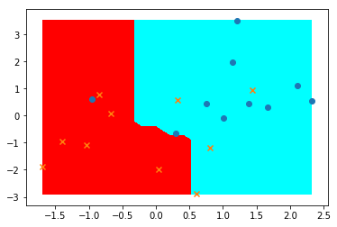

```python
foret = ClassifierBaggingTree(10,0.3,0.0,True)
foret.train(set_exemples)
for i in range(set_exemples.size()):
    print("exemple:",i," vraie classe = ", set_exemples.getY(i), "- classe trouvee = ", foret.predict(set_exemples.getX(i)))

ut.plot_frontiere(set_exemples,foret,20)
ut.plot2DSet(set_exemples)

print("\naccuracy totale:",foret.accuracy(set_exemples))
```

### Expérimentations

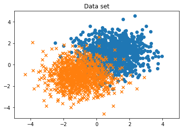

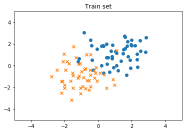

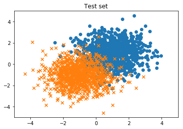

```python
# Réaliser un apprentissage par bagging sur E et évaluer le taux de prédiction du modèle sur F
foret20 =  ClassifierBaggingTree(20,0.3,0.0,True)
foret20.train(E)
print("Bagging : 20 trees: accuracy totale: train=%.4f test=%.4f"%(foret20.accuracy(E),foret20.accuracy(F)))
```

```
Bagging : 20 trees: accuracy totale: train=0.9200 test=0.8947
```

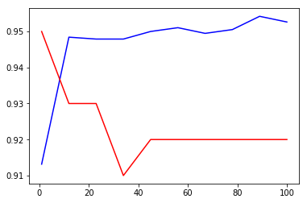

### Evaluation par la méthode "Out Of Bags"

**[Q]** Sur les mêmes données, réaliser une évaluation par la méthode "Out Of Bags" vue en cours. Construire la courbe donnant le taux de prédiction OOB en fonction de la taille de la forêt d'arbres.

Pour cela, écrire la classe `ClassifierBaggingTreeOOB` qui étend la classe d'un classifieur bagging pour prendre en compte la spécificité de l'approche OOB. Ainsi, à partir de $\mathcal{X}$, l'ensemble des données d'apprentissage, chaque arbre $A_i$ de la forêt est associé à 2 sous-ensembles de $\mathcal{X}$:

- $\mathcal{X}_i$: l'échantillon bootstrap qui sert à construire l'arbre $A_i$
- $\mathcal{T}_i$: l'ensemble des exemples OOB associés à l'arbre $A_i$

Le calcul du taux de bonne classification s'effectuera comme suit:

- soit $t_i$ le taux de bonne classification de $A_i$ pour l'ensemble OOB $\mathcal{T}_i$
- le taux de global de bonne classification de la forêt d'arbres $A_1$,..., $A_B$ est donné par $\frac{1}{B}\sum_{i=1}^{B} t_i$

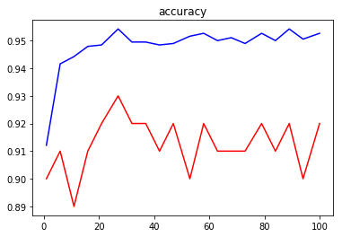

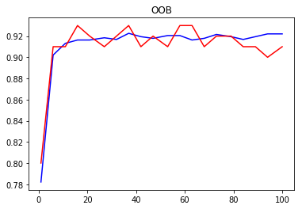

## Etape 3: Random forests

**[Q]** Ecrire et tester la classe `ClassifierRandomForest` qui implémente l'algorithme des random forests vu en cours.

Pour cela, vous devrez:

- définir une méthode `construit_AD_aleatoire(LSet,epsilon,nbatt)` qui utilise $nbatt$ attributs choisis aléatoirement à chaque niveau de la construction de l'arbre
- définir une nouvelle classe `ArbreDecisionAleatoire` qui étend la classe `ArbreDecision` en surchargeant la méthode `train`. Le constructeur d'un tel arbre prendra en argument le nombre d'attributs à utiliser lors de la construction de l'arbre.

## Etape 4: expérimentation

**[Q]** Comparer le bagging d'arbres et les random forests sur d'autres bases d'apprentissage (réelles ou générées aléatoirement). Construire la courbe donnant le taux de prédiction pour une forêt d'arbres variant de 1 à 100 arbres (cela peut prendre du temps, tester sur un nombre réduit d'arbres dans un premier temps).

## Exercices à faire chez vous (sur papier)

Pour vous entraîner sans machine... *(exercice de l'examen 2017)*

Soit $V=\{v_{1}, v_{2},..., v_{n}\}$ un ensemble de $n$ valeurs réelles ordonnées, telles que $v_1 \geq v_2 \geq \ldots \geq v_{n}$.. On note $\bar{v}$ la valeur moyenne de $V$. La variance de $V$, $var(V)$ est définie par: $var(V) = \frac{1}{n} \sum_{i=1}^{n} (v_{i} - \bar{v})^2$.

**[Q]** Donner l'expression de $\bar{v}$ en fonction des valeurs de $V$.

**[Q]** Montrer que $var(aV+b) = a^2 var(V)$.

**[Q]** Donner l'expression de $V\cdot W$ (le produit scalaire) en fonction des coordonnées de $V$ et de $W$.

**[Q]** Comment doit-on définir $W$ si on souhaite que $V\cdot W = \bar{v}$ ?

**[Q]** Comment doit-on définir $W$ si on souhaite que $V\cdot W = \displaystyle\max_{i=1,...n} v_i$ ? Même question si on souhaite que $V\cdot W = \displaystyle\min_{i=1,...n} v_i$ ?

**[Q]** Soit un entier $k$ tel que $0<k\leq n$. Proposer une définition de $W$ qui, par le calcul du produit scalaire, permet de ne tenir compte, de façon équitable, que des $k$ valeurs les plus élevées de $V$.